# NFL_Fantasy_Scores_And_Player_Performance

Darshil Patel

# Exploration and Modeling of NFL Player Fantasy Performance

This notebook contains code and text for the final project of DS4100 Data Collection, and Analysis.

For my final project I explored NFL player fanstasy performance and indvividual in-game player performance. One of the goals of this project is to model fantasy football scores using player performance metrics and identify key metrics that might help an individual pick fanstasy players for their next draft.

The predictions will be of seasonal performance and not weekly game to game fantasy performance.

## The analytics process of this project is as follows:

1. Data Collection/Acquistion:

For this project I will be using an an API called ffanalytics to pull in player data which can retrieve fantasy scores and game performance.I will store the data in a database which I will query to get the data points for my analysis.

2. Data Exploration and Cleaning

For this step I will make simple visualizations of my data to get a sense of its properties and distributions. At this step I will also deal with NA values and outliers (I may choose to keep outliers if the model suffers from removing them)

3. Data Storage

I will store the data in a database which I will query to get the data points for my analysis. This may form multiple tables which I will join to retrieve the appropriate data.

4. Data Visualization and Further Exploration

Here I will visualize the data with more complexity in order to distill information about players and teams. Here I will split my visualizations based on aggregated player data and split by metrics such as player position.

5. Data Modeling

Using the information from the above steps I plan on using multiple linear regression to model fantasy football scores. I will split my data into training/testing subsets and iteratively add and remove features. If the above analysis provides rationale for an alternate model I will apply other models to perhaps achieve a better predictor. The data will be put into the model using backwards fitting for comparison of models.

## Data Collection/Acquisition

```r
# First we will install the required packages needed to use the ffanalytics API
# NO NEED TO RUN IF ALREADY INSTALLED (Comment out and run the following if needed)

#install.packages(c("devtools"), dependencies=TRUE, repos=c("http://rstudio.org/_packages", "http://cran.rstudio.com"))
#devtools::install_github(repo = "FantasyFootballAnalytics/ffanalytics", build_vignettes = TRUE)
```

```r
library(ffanalytics)
```

```r
# Now we will use the API to scrape data from various sources for fantasy football information

# First we will take in player information for all scoring offensive positions
# The postions are: Quarterback, Runningback, Wide Reciever, Tight End, and Defense/Special Teams
player_data <- scrape_data(src = c("Yahoo"),
                         pos = c("QB", "RB", "WR", "TE", "DST"),
                         season = 2018, week = 0) # Week 0 of 2018 retrieves the 2016-2017 totals
```

```
## Scraping QB projections from
##  https://football.fantasysports.yahoo.com/f1/48938/players?sort=PTS&sdir=1&status=A&pos=QB&stat1=S_PS_2018&jsenabled=1&count=0
## Scraping RB projections from
##  https://football.fantasysports.yahoo.com/f1/48938/players?sort=PTS&sdir=1&status=A&pos=RB&stat1=S_PS_2018&jsenabled=1&count=0
## Scraping WR projections from
##  https://football.fantasysports.yahoo.com/f1/48938/players?sort=PTS&sdir=1&status=A&pos=WR&stat1=S_PS_2018&jsenabled=1&count=0
## Scraping TE projections from
##  https://football.fantasysports.yahoo.com/f1/48938/players?sort=PTS&sdir=1&status=A&pos=TE&stat1=S_PS_2018&jsenabled=1&count=0
## Scraping DST projections from
##  https://football.fantasysports.yahoo.com/f1/48938/players?sort=PTS&sdir=1&status=A&pos=DEF&stat1=S_PS_2018&jsenabled=1&count=0
```

```r
head(player_data)
```

```
## $QB
## # A tibble: 134 x 45
##    data_src id    src_id z     note  player team  pos   status_game_opp
##    <chr>    <chr> <chr>  <chr> <chr> <chr>  <chr> <chr> <chr>
##  1 Yahoo    13116 30123  "\ue~ Play~ P. Ma~ KC    QB    "Sun 10:00 am ~
##  2 Yahoo    10273 24788  "\ue~ Play~ C. Ne~ Car   QB    "Sun 10:00 am ~
##  3 Yahoo    7401  6770   "\ue~ Play~ B. Ro~ Pit   QB    "Sun 1:25 pm  ~
##  4 Yahoo    4925  5479   "\ue~ Play~ D. Br~ NO    QB    "Sun 10:00 am ~
##  5 Yahoo    12611 29235  "\ue~ Play~ J. Go~ LAR   QB    "Sun 5:20 pm  ~
##  6 Yahoo    9099  8780   "\ue~ Play~ M. Ry~ Atl   QB    "Sun 10:00 am ~
##  7 Yahoo    10695 25711  "\ue~ Play~ A. Lu~ Ind   QB    "Sun 10:00 am ~
##  8 Yahoo    7394  6763   "\ue~ Play~ P. Ri~ LAC   QB    Sun 1:05 pm   ~
##  9 Yahoo    13113 30125  "\ue~ Play~ D. Wa~ Hou   QB    "Sun 10:00 am ~
## 10 Yahoo    10703 25785  "\ue~ Play~ R. Wi~ Sea   QB    "Mon 5:15 pm  ~
## # ... with 124 more rows, and 36 more variables: z1 <chr>, forecast <chr>,
## #   owner <chr>, games <dbl>, bye <dbl>, site_pts <dbl>,
## #   fantasy_percent_owned <chr>, rankings_proj <chr>,
## #   rankings_actual <chr>, pass_att <dbl>, pass_comp <dbl>,
## #   pass_inc <dbl>, pass_yds <dbl>, pass_tds <dbl>, pass_int <dbl>,
## #   passing_pick_six <chr>, sacks <dbl>, pass_1st <dbl>,
## #   pass_40_yds <dbl>, rush_att <dbl>, rush_yds <dbl>, rush_tds <dbl>,
## #   rush_1st <dbl>, rush_40_yds <dbl>, rec_tgt <dbl>, rec <dbl>,
## #   rec_yds <dbl>, rec_tds <dbl>, rec_1st <dbl>, rec_40_yds <dbl>,
## #   ret_yds <dbl>, ret_tds <dbl>, two_pts <dbl>, fumbles_total <dbl>,
## #   fumbles_lost <dbl>, na <lgl>
##
## $RB
## # A tibble: 281 x 45
##    data_src id    src_id z     note  player team  pos   status_game_opp
##    <chr>    <chr> <chr>  <chr> <chr> <chr>  <chr> <chr> <chr>
##  1 Yahoo    12150 28398  "\ue~ Play~ T. Gu~ LAR   RB    "Sun 5:20 pm  ~
##  2 Yahoo    13604 30972  "\ue~ Play~ S. Ba~ NYG   RB    "Sun 10:00 am ~
##  3 Yahoo    13130 30121  "\ue~ Play~ C. Mc~ Car   RB    "Sun 10:00 am ~
##  4 Yahoo    13132 30180  "\ue~ Play~ A. Ka~ NO    RB    "Sun 10:00 am ~
##  5 Yahoo    12625 29238  "\ue~ Play~ E. El~ Dal   RB    "Sun 1:25 pm  ~
##  6 Yahoo    13146 30218  "\ue~ Play~ J. Co~ Pit   RB    O
##  7 Yahoo    12151 28403  "\ue~ Play~ M. Go~ LAC   RB    O
##  8 Yahoo    11747 27658  "\ue~ Play~ J. Wh~ NE    RB    "Sun 10:00 am ~
##  9 Yahoo    13614 31379  "\ue~ Play~ P. Li~ Den   RB    "Sun 1:05 pm  ~
## 10 Yahoo    12171 28474  "\ue~ Play~ D. Jo~ Ari   RB    "Sun 1:25 pm  ~
```

[output cut: 70 more lines]

```
##  3 Yahoo    0528  14     "\ue~ No n~ Los A~ LAR   DEF   "Sun 5:20 pm  ~
##  4 Yahoo    0511  7      "\ue~ No n~ Denver Den   DEF   "Sun 1:05 pm  ~
##  5 Yahoo    0524  16     "\ue~ No n~ Minne~ Min   DEF   "Mon 5:15 pm  ~
##  6 Yahoo    0504  17     "\ue~ No n~ New E~ NE    DEF   "Sun 10:00 am ~
##  7 Yahoo    0512  12     "\ue~ No n~ Kansa~ KC    DEF   "Sun 10:00 am ~
##  8 Yahoo    0531  33     "\ue~ No n~ Balti~ Bal   DEF   "Sun 10:00 am ~
##  9 Yahoo    0503  15     "\ue~ No n~ Miami  Mia   DEF   "Sun 10:00 am ~
## 10 Yahoo    0520  28     "\ue~ No n~ Washi~ Was   DEF   "Sun 10:00 am ~
## # ... with 22 more rows, and 22 more variables: z1 <chr>, owner <chr>,
## #   games <dbl>, bye <dbl>, site_pts <dbl>, fantasy_percent_owned <chr>,
## #   rankings_proj <chr>, rankings_actual <chr>, dst_pts_allowed <dbl>,
## #   dst_sacks <dbl>, dst_safety <dbl>, dst_tfl <dbl>, dst_int <dbl>,
## #   dst_fum_rec <dbl>, dst_td <dbl>, dst_blk <dbl>, dst_4_down <dbl>,
## #   dst_yds_allowed <dbl>, dst_3_out <dbl>, dst_ret_yds <dbl>,
## #   dst_ret_tds <dbl>, na <lgl>
```

## Data Exploration

On first inspection it seems the data is split into 5 data frames pertaining to each position

We will to merge the postions to create a model later and also keep seperate to see if separating by postion gives better predictions.

1. Next we will merge the data into a single data frame
2. After storing the data the pos column will allow us to split and analyze the data based on positions

```r
# The tables for QB, WR, TE, and RB have common columns so we can stack the rows using rbind
player_data_merged <- rbind(player_data$QB, player_data$RB, player_data$WR, player_data$TE)

# Defensive and special teams players have their own unique metrics that we have to
player_data_final <- plyr::rbind.fill(player_data_merged, player_data$DST)

head(dplyr::filter(player_data_final, player_data_final$pos == "DEF"))
```

```
##   data_src   id src_id        z                note      player team pos
## 1    Yahoo 0521      3  No new player Notes     Chicago  Chi DEF
## 2    Yahoo 0532     34  No new player Notes     Houston  Hou DEF
## 3    Yahoo 0528     14  No new player Notes Los Angeles  LAR DEF
## 4    Yahoo 0511      7  No new player Notes      Denver  Den DEF
## 5    Yahoo 0524     16  No new player Notes   Minnesota  Min DEF
## 6    Yahoo 0504     17  No new player Notes New England   NE DEF
##                           status_game_opp       z1 forecast owner games
## 1  Sun 5:20 pm            vs  LAR      <NA>    FA    16
## 2 Sun 10:00 am            vs  Ind      <NA>    FA    16
## 3   Sun 5:20 pm            @  Chi      <NA>    FA    16
## 4    Sun 1:05 pm            @  SF      <NA>    FA    16
## 5   Mon 5:15 pm            @  Sea      <NA>    FA    16
## 6  Sun 10:00 am            @  Mia      <NA>    FA    16
##   bye site_pts fantasy_percent_owned rankings_proj rankings_actual
```

[output cut: 48 more lines]

For the next steps in the analysis we will visualize the distribution of variable split by position

Passing Statistics distribution

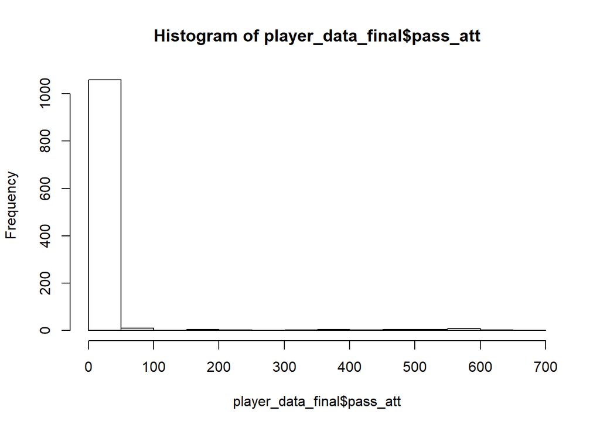

```r
passing_data <- subset(player_data_final, select = pass_att:passing_pick_six)
hist(player_data_final$pass_att)
```

## Data Cleaning

We will first deal with outliers in our data, split by postion. We are doing this before any visualizations because inspection of the data shows many players do not get playing time (above) and thus have low sometimes zero for many of their statistics (We will eliminate those players from the data set)

Passing Statistics Outlier Detection and Removal

```r
# We will first aggregate the statistics by summing over those columns
pass_cols <- c("pass_att", "pass_comp", "pass_inc", "pass_yds", "pass_tds", "pass_int")
qbacks <- filter(player_data_final, player_data_final$pos == "QB")

passers <- qbacks %>%
       replace(is.na(.), 0) %>%
       mutate(sum = rowSums(.[,pass_cols]))

avg_pass <- mean(passers$sum)
passers <- passers[passers$sum > avg_pass - 500, ] # Outliers are based on aggregated passer performance average minus a                                                         threshold determined by me based on the aggregates

qbacks <- passers[,1:length(passers) - 1] # remove summed aggregates
```

Receiving Statistics Outlier Detection and Removal

```r
# We will first aggregate the statistics by summing over those columns
rec_cols <- c( "rec_tgt", "rec", "rec_yds", "rec_tds", "rec_1st", "rec_40_yds", "ret_yds", "ret_tds")
recievers <- filter(player_data_final, player_data_final$pos %in% c("WR", "TE"))

recs <- recievers %>%
       replace(is.na(.), 0) %>%
       mutate(sum = rowSums(.[,rec_cols]))

avg_rec <- mean(recs$sum)
recs<- recs[recs$sum > avg_rec, ]  # Outliers are based on aggregated recieving performance average (the average is                                            skewed toward lower aggregates)

recievers <- recs[,1:length(recs) - 1] # remove summed aggregates
```

Rushing Statistics Outlier Detection and Removal

```r
rush_cols <- c("rush_att", "rush_yds", "rush_tds", "rush_1st", "rush_40_yds")
rushers <- filter(player_data_final, player_data_final$pos =="RB")

rb <-  rushers %>%
       replace(is.na(.), 0) %>%
       mutate(sum = rowSums(.[,rush_cols]))

avg_rush <- mean(rb$sum)
rb<- rb[rb$sum > avg_rush, ]  # Outliers are based on aggregated recieving performance average (the average is                                            skewed toward lower aggregates)
rb <- rb[,1:length(rb) - 1] # remove summed aggregates
```

For Defense/Special Teams rows the metrics represent an enitre team and this problem is not present and if it is there are very few points so we will keep all the DSTs

```r
# Collect the data without the outliers into a single dataset
dsts<- filter(player_data_final, player_data_final$pos == "DEF")
players_data_out <- rbind(qbacks, recievers, rb, dsts)

head(dsts) # Check out defensive players
```

```
##   data_src   id src_id        z                note      player team pos
## 1    Yahoo 0521      3  No new player Notes     Chicago  Chi DEF
## 2    Yahoo 0532     34  No new player Notes     Houston  Hou DEF
## 3    Yahoo 0528     14  No new player Notes Los Angeles  LAR DEF
## 4    Yahoo 0511      7  No new player Notes      Denver  Den DEF
## 5    Yahoo 0524     16  No new player Notes   Minnesota  Min DEF
## 6    Yahoo 0504     17  No new player Notes New England   NE DEF
##                           status_game_opp       z1 forecast owner games
## 1  Sun 5:20 pm            vs  LAR      <NA>    FA    16
## 2 Sun 10:00 am            vs  Ind      <NA>    FA    16
## 3   Sun 5:20 pm            @  Chi      <NA>    FA    16
## 4    Sun 1:05 pm            @  SF      <NA>    FA    16
## 5   Mon 5:15 pm            @  Sea      <NA>    FA    16
## 6  Sun 10:00 am            @  Mia      <NA>    FA    16
##   bye site_pts fantasy_percent_owned rankings_proj rankings_actual
```

[output cut: 48 more lines]

Converting fantasy owned percentages to numeric

```r
#We will use the percent owned column in the table for our model so we need to convert it from a string to a number
players_data_out$fantasy_percent_owned <- lapply(players_data_out$fantasy_percent_owned, FUN = function(x) X =                                                               as.numeric(gsub("%","", x))/100)
players_data_out$fantasy_percent_owned <- unlist(players_data_out$fantasy_percent_owned)
dplyr::filter(players_data_out, players_data_out$pos == "QB")$fantasy_percent_owned
```

```
##  [1] 0.99 0.99 0.97 1.00 0.97 0.96 0.95 0.96 0.97 0.95 0.99 0.95 0.72 0.98
## [15] 0.56 0.89 0.18 0.64 0.21 0.59 0.33 0.20 0.64 0.14 0.20 0.04 0.12 0.15
## [29] 0.11 0.06 0.04 0.45 0.15 0.07 0.02 0.01 0.01 0.01 0.01 0.10
```

### Handling NA Values

```r
numeric_cols <- c(pass_cols, rush_cols, rec_cols, c("dst_pts_allowed", "dst_sacks", "dst_safety", "dst_tfl",
                                                 "dst_fum_rec", "dst_td", "dst_blk", "dst_4_down", "dst_yds_allowed",                                                            "dst_3_out", "dst_ret_yds", "dst_ret_tds"))
players_temp <- players_data_out

for(i in numeric_cols){
  players_data_out[is.na(players_data_out[,i]), i] <- mean(players_data_out[,i], na.rm = TRUE)
}

head(players_data_out)
```

```
##   data_src    id src_id        z        note            player team pos
## 1    Yahoo 13116  30123  Player Note        P. Mahomes   KC  QB
## 2    Yahoo 10273  24788  Player Note         C. Newton  Car  QB
## 3    Yahoo  7401   6770  Player Note B. Roethlisberger  Pit  QB
## 4    Yahoo  4925   5479  Player Note          D. Brees   NO  QB
## 5    Yahoo 12611  29235  Player Note           J. Goff  LAR  QB
## 6    Yahoo  9099   8780  Player Note           M. Ryan  Atl  QB
##                           status_game_opp       z1       forecast owner
## 1 Sun 10:00 am            vs  Bal  Video Forecast    FA
## 2  Sun 10:00 am            @  Cle  Video Forecast    FA
## 3   Sun 1:25 pm            @  Oak  Video Forecast    FA
## 4   Sun 10:00 am            @  TB  Video Forecast    FA
## 5   Sun 5:20 pm            @  Chi  Video Forecast    FA
## 6   Sun 10:00 am            @  GB  Video Forecast    FA
##   games bye site_pts fantasy_percent_owned rankings_proj rankings_actual
```

[output cut: 48 more lines]

## Data Storage and Retrieval

At this point we have good quality data that we hope to put into our model. So We will create a database and then retrieve the data from our database for the rest of our analysis

```r
library(RSQLite)
db <- dbConnect(SQLite(), dbname="fantasy.sqlite")

# We will write the data into a new table in the database
dbWriteTable(conn = db, name = "players", value = players_data_out,  row.names = FALSE, header = TRUE, overwrite = TRUE)

# Now that we have made the database we can retrieve the data from it
players <- dbReadTable(db, "players")

dbDisconnect(db)
```

Let’s see if our storage and retrieval worked correctly

```r
head(players)
```

```
##   data_src    id src_id        z        note            player team pos
## 1    Yahoo 13116  30123  Player Note        P. Mahomes   KC  QB
## 2    Yahoo 10273  24788  Player Note         C. Newton  Car  QB
## 3    Yahoo  7401   6770  Player Note B. Roethlisberger  Pit  QB
## 4    Yahoo  4925   5479  Player Note          D. Brees   NO  QB
## 5    Yahoo 12611  29235  Player Note           J. Goff  LAR  QB
## 6    Yahoo  9099   8780  Player Note           M. Ryan  Atl  QB
##                           status_game_opp       z1       forecast owner
## 1 Sun 10:00 am            vs  Bal  Video Forecast    FA
## 2  Sun 10:00 am            @  Cle  Video Forecast    FA
## 3   Sun 1:25 pm            @  Oak  Video Forecast    FA
## 4   Sun 10:00 am            @  TB  Video Forecast    FA
## 5   Sun 5:20 pm            @  Chi  Video Forecast    FA
## 6   Sun 10:00 am            @  GB  Video Forecast    FA
##   games bye site_pts fantasy_percent_owned rankings_proj rankings_actual
```

[output cut: 48 more lines]

## Data Exploration (Continued)

### Distribution of Variables

Now we will look at the distributions of variables split by position

There are many variables so to keep the plotting concise I will lay all of them out in a grid of so we can see all of them quickly and at the same time

Passing variables

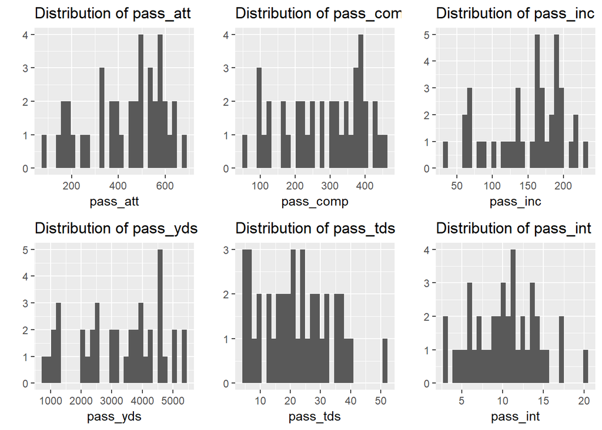

```r
pass_plot_cols <- passers[, pass_cols]

list <-lapply(pass_cols,
              function(col) qplot(pass_plot_cols[,col], xlab = col, main = paste("Distribution of", col)))

cowplot::plot_grid(plotlist = list)
```

The passing variables are very discrete and are not very normal at all. There is however some concentration round the means and atendecny towards higher values across pass_inc, pass_att, and pass_comp variables. The distribution shape might be indicative of the fact that the quaterback sample is too small there are roughly over 30 quaterbacks we chose to include in the data set

Recieving Variables

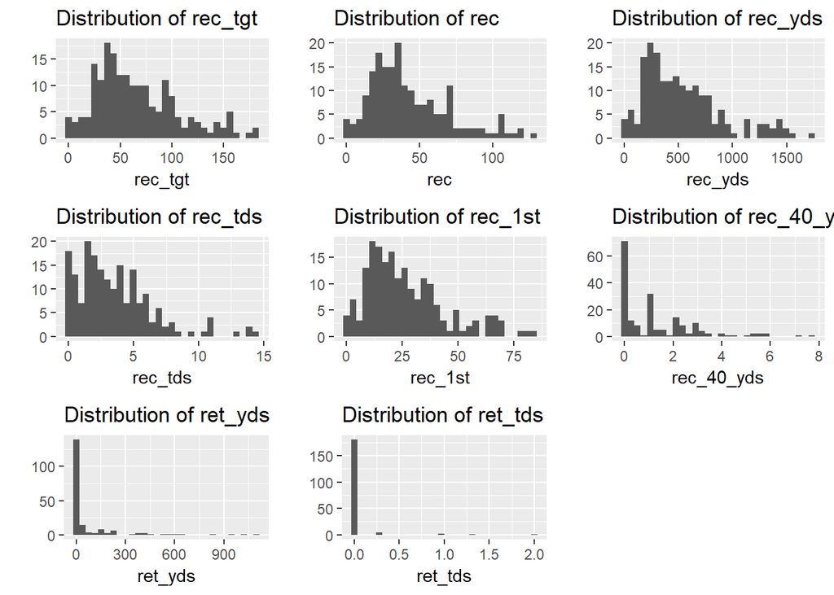

```r
rec_plot_cols <- recs[, rec_cols]

list <-lapply(rec_cols,
              function(col) qplot(rec_plot_cols[,col], xlab = col, main = paste("Distribution of", col)))

cowplot::plot_grid(plotlist = list)
```

These distributions make us confident that there is a sufficient sample of recievers since the data looks more continuous than for quarterbacks. TheFirst 5 of these data distributions are skewed right, but around the mean show some degree of normality.

The final 3 distributions just show how rare such plays are for recievers a subset of recievers return kicks which is what these represent. Thus the data is much more spare and tends toward zero.

rec_40_yds which represents 40 yard receptions are also rare and may indicate better fantasy performance

Rushing Variables

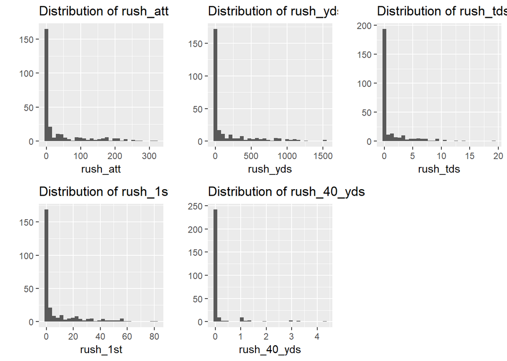

```r
rush_plot_cols <- rushers[, rush_cols]

list <-lapply(rush_cols,
              function(col) qplot(rush_plot_cols[,col], xlab = col, main = paste("Distribution of", col)))

cowplot::plot_grid(plotlist = list)
```

These distributions are indicitive of the nature of rushing in the NFL which for many teams and runningbacks tends to give lower (tending toward zero) yardage and points.

Defense/Special Teams Variables

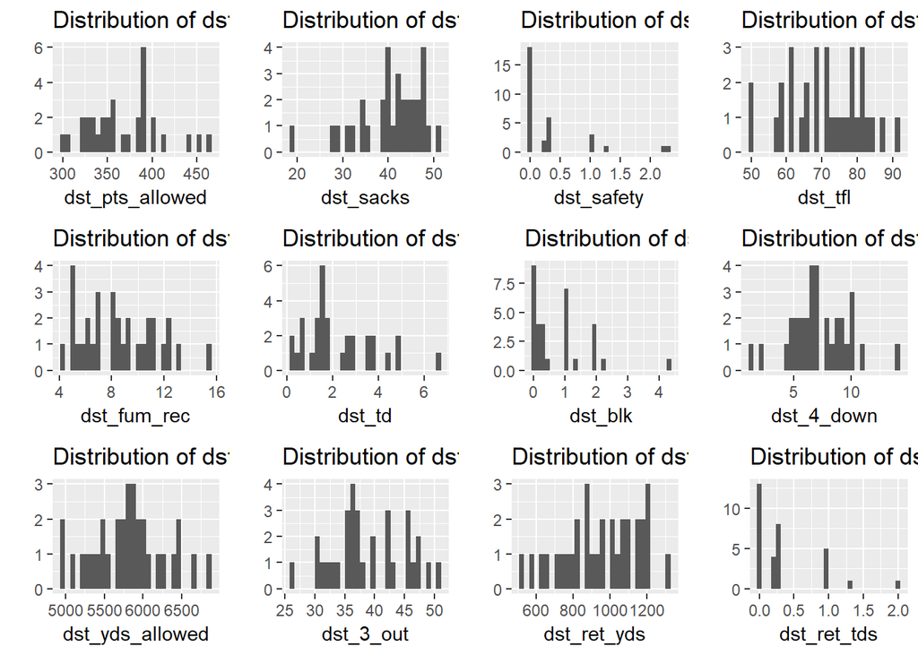

```r
dst_cols <- c("dst_pts_allowed", "dst_sacks", "dst_safety", "dst_tfl",
              "dst_fum_rec", "dst_td", "dst_blk", "dst_4_down", "dst_yds_allowed",                                                             "dst_3_out", "dst_ret_yds", "dst_ret_tds")

dst_plot_cols <- dsts[, dst_cols]

list <-lapply(dst_cols,
              function(col) qplot(dst_plot_cols[,col], xlab = col, main = paste("Distribution of", col)))

cowplot::plot_grid(plotlist = list)
```

These variables are not continuous as was the case with some of the previous positions. In these distributions we see greater variance. The plots are more spread out with peaks scattered locally across the x-axis. This will be interesting to see when we compare these to the independent variables such as overall points.

### Correlation/Collinearity Analysis

Again we will split our analysis by position

Since we have many variables we will use a correlogram to visualize our correlations and then observe and go more into depth on select variables.

```r
library(corrplot)
```

Passing CorrPlot

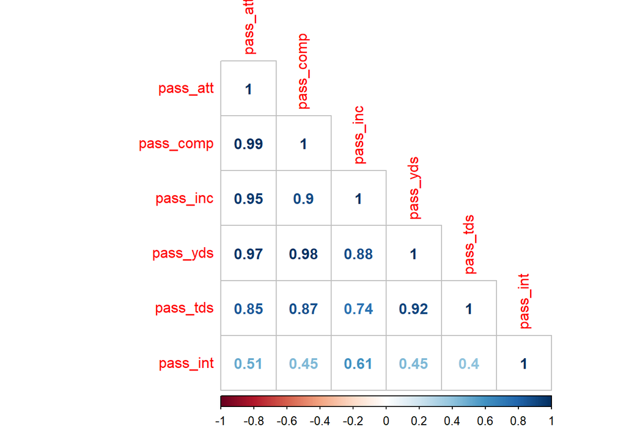

```r
passing_corr_matrix <-cor(passers[, pass_cols])

corrplot(passing_corr_matrix, method = "number", type = "lower")
```

Recieving CorrPlot

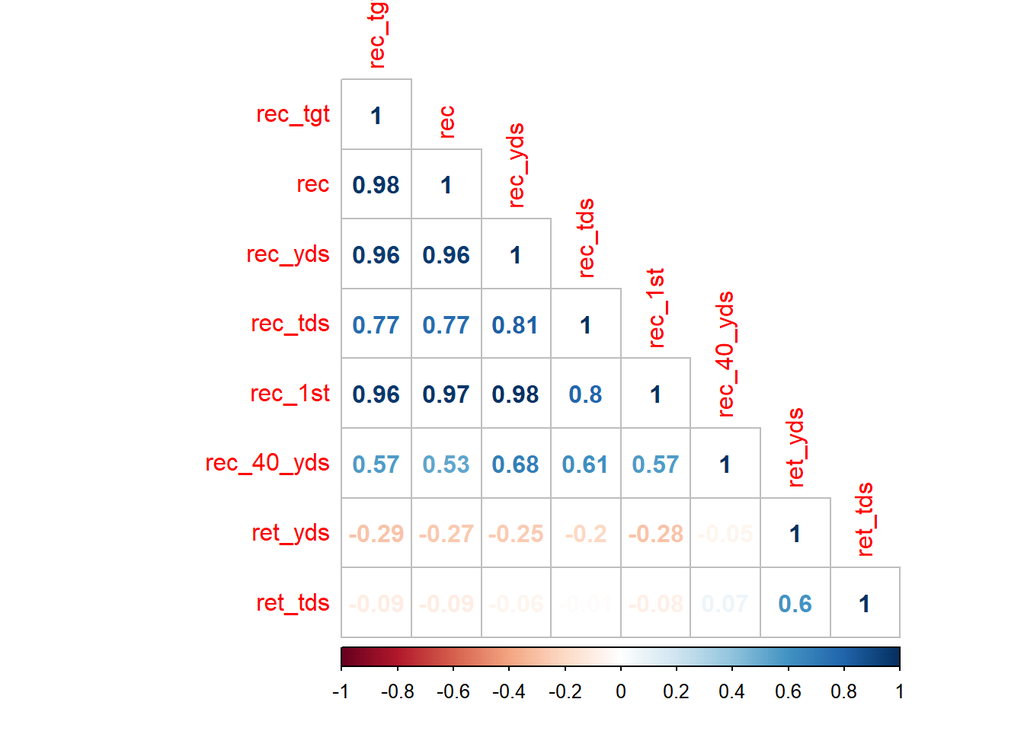

```r
rec_corr_matrix <-cor(recs[, rec_cols])

corrplot(rec_corr_matrix, method = "number", type = "lower")
```

Rushing CorrPlot

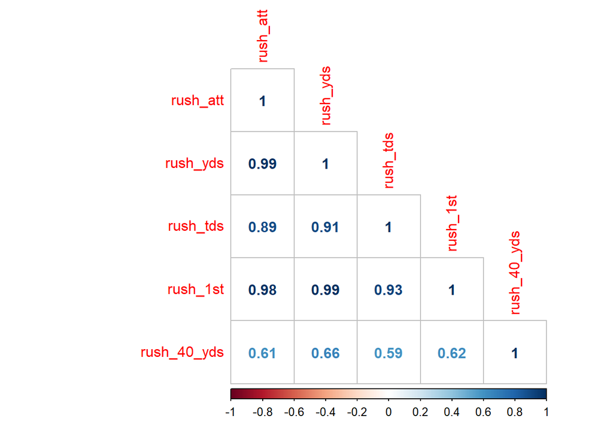

```r
rush_corr_matrix <-cor(rushers[, rush_cols])

corrplot(rush_corr_matrix, method = "number", type = "lower")
```

Defense/Special Teams CorrPlot

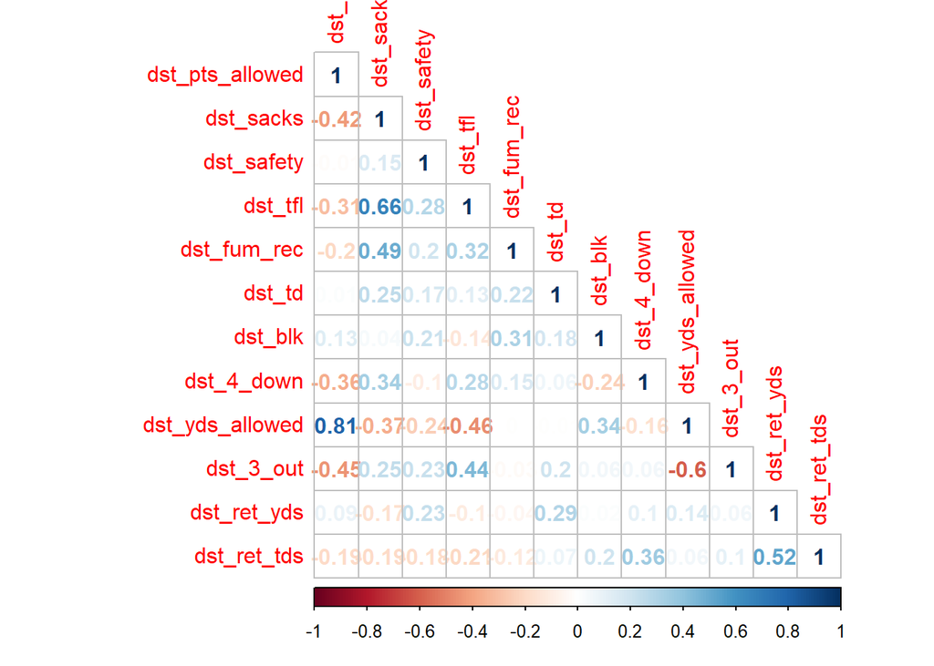

```r
dst_corr_matrix <-cor(dsts[, dst_cols])

corrplot(dst_corr_matrix, method = "number", type = "lower")
```

Overall CorrPlot (All numeric metrics)

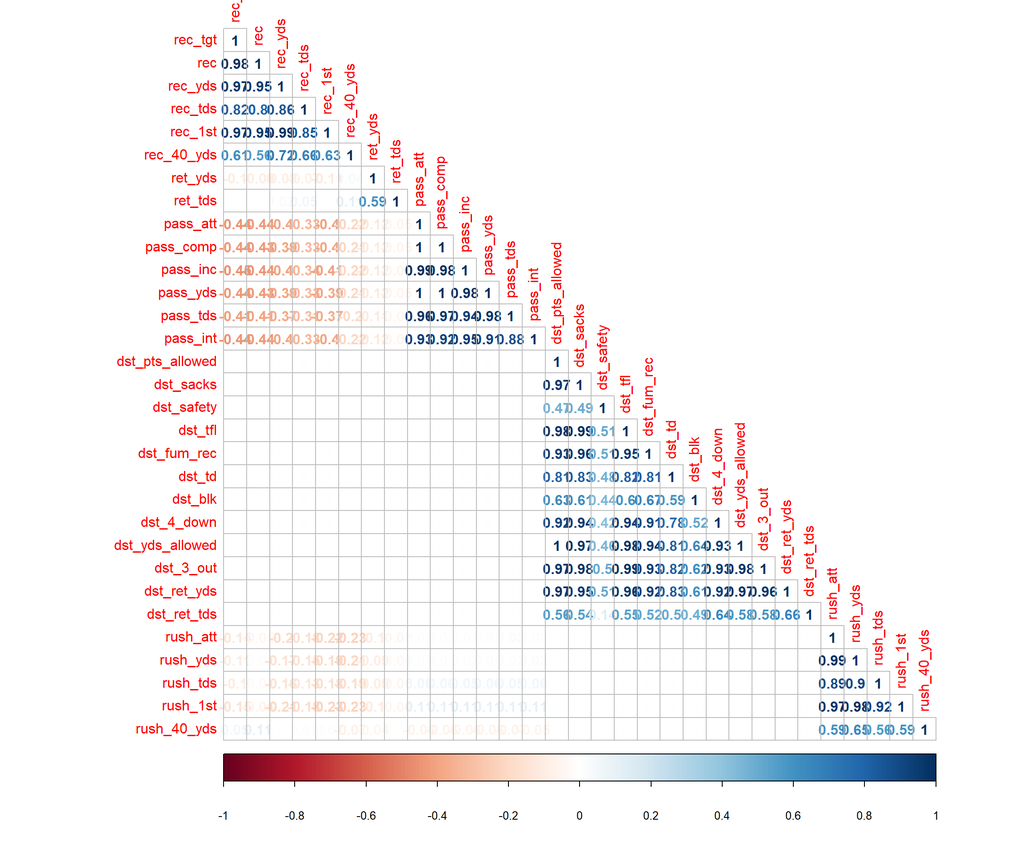

```r
big_corr_matrix <-cor(players[, c(rec_cols, pass_cols, dst_cols, rush_cols)])

corrplot(big_corr_matrix, method = "number", type = "lower")
```

Evaluation of Correlations:

For passing most metrics are positivey correlated as expected with pass interceptions being less tied to the positive performance metrics like passing yards.

For recievers it looks like return tds and yards are negatively correlated with other metrics which points to the fact that recievers who perform this functions do not see regular play (rec_tds, rec_yds, etc.)

For rushing there were fairly positive correlations throughout.

The case for defensive/special teams positions low or negative correlations were more prevalent with each other. This shows that better performance on the defensive end for one area may hinder others (ex. defense return tds vs defensive sacks.

With the large correlation plot of our variables we see that significant correlations are concentrated within positions (ex. passing metrics to other passing metrics)

### Visualization of Independent Variables to Dependent Variable

For this section we will employ the same strategy we used for the variable distributions. Except this time we will plot the independent player metrics against the fantasy points (site_pts) variable. Split by position.

Passing

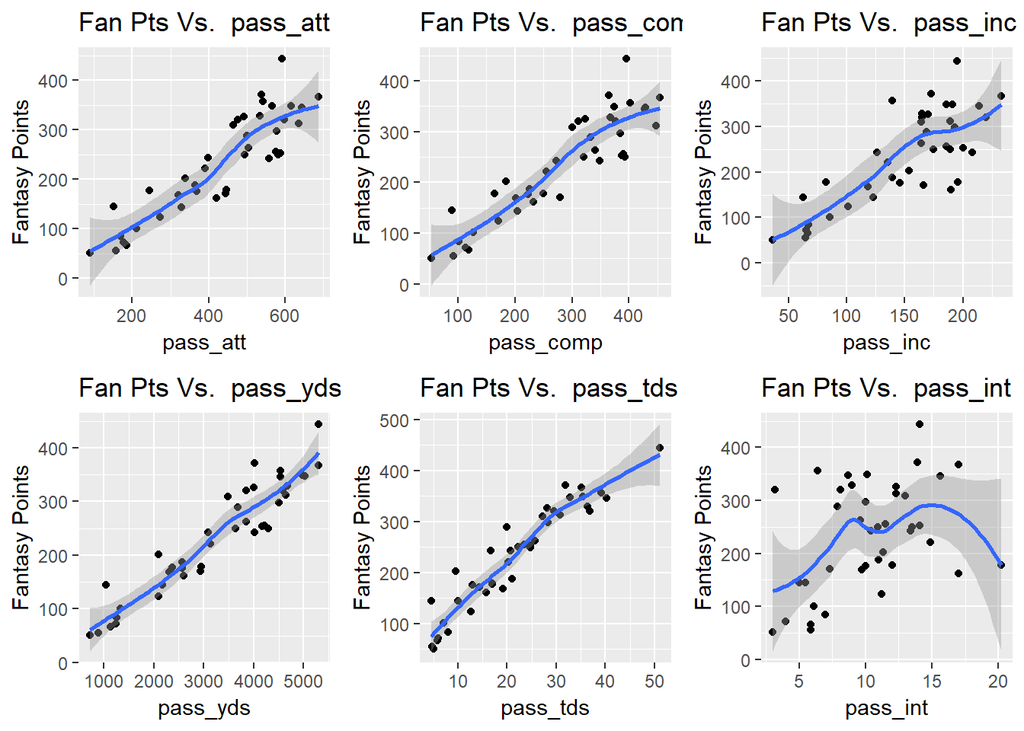

```r
pass_plot_cols <- passers[, c(pass_cols, "site_pts")]

list <-lapply(pass_cols,
              function(col) qplot(x = pass_plot_cols[,col], y = pass_plot_cols[,"site_pts"], xlab = col, ylab = "Fantasy Points",                                     geom = c("point", "smooth"), main = paste("Fan Pts Vs. ", col)))

cowplot::plot_grid(plotlist = list)
```

Recieving

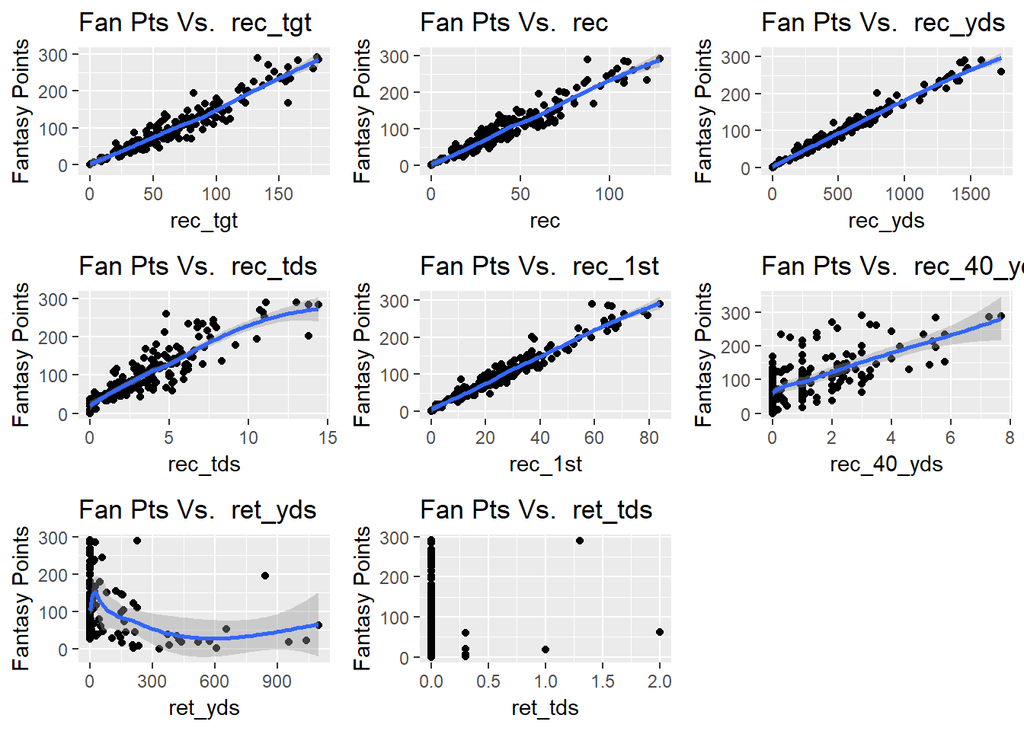

```r
rec_plot_cols <- recs[, c(rec_cols, "site_pts")]

list <-lapply(rec_cols,
              function(col) qplot(x = rec_plot_cols[,col], y = rec_plot_cols[,"site_pts"], xlab = col, ylab = "Fantasy Points",                                     geom = c("point", "smooth"), main = paste("Fan Pts Vs. ", col)))

cowplot::plot_grid(plotlist = list)
```

The positive relationhips are expected, but the negative and no relation is unusual. For the ret_tds feature this may mean we have to remove it from our feature set. The negative relationship with ret_yds may again indicate that players serving as returners get less regular reciever duties and thus less fantasy points

Rushing

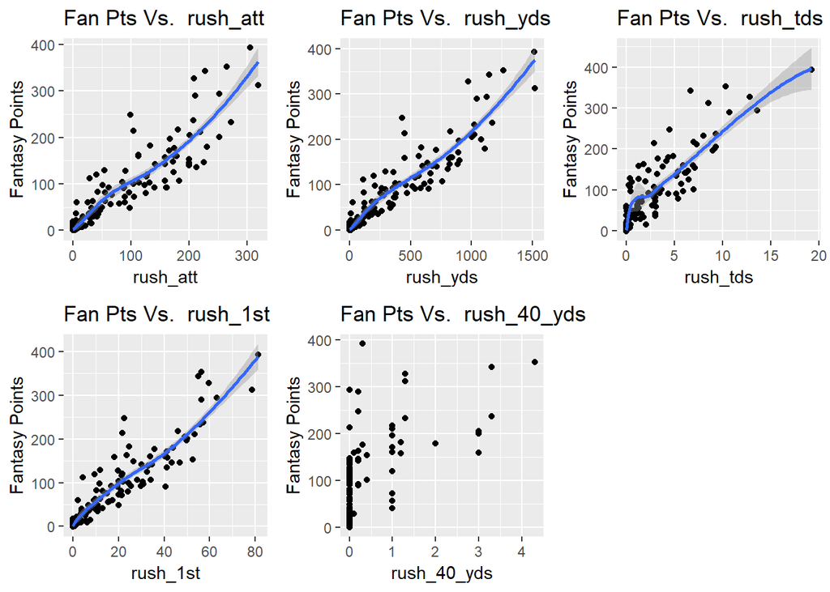

```r
rush_plot_cols <- rushers[, c(rush_cols, "site_pts")]

list <-lapply(rush_cols,
              function(col) qplot(x = rush_plot_cols[,col], y = rush_plot_cols[,"site_pts"], xlab = col, ylab = "Fantasy Points",                                     geom = c("point", "smooth"), main = paste("Fan Pts Vs. ", col)))

cowplot::plot_grid(plotlist = list)
```

Again postive relations. The last variable might also be a candidate for removal from our features

Defense/Special Teams

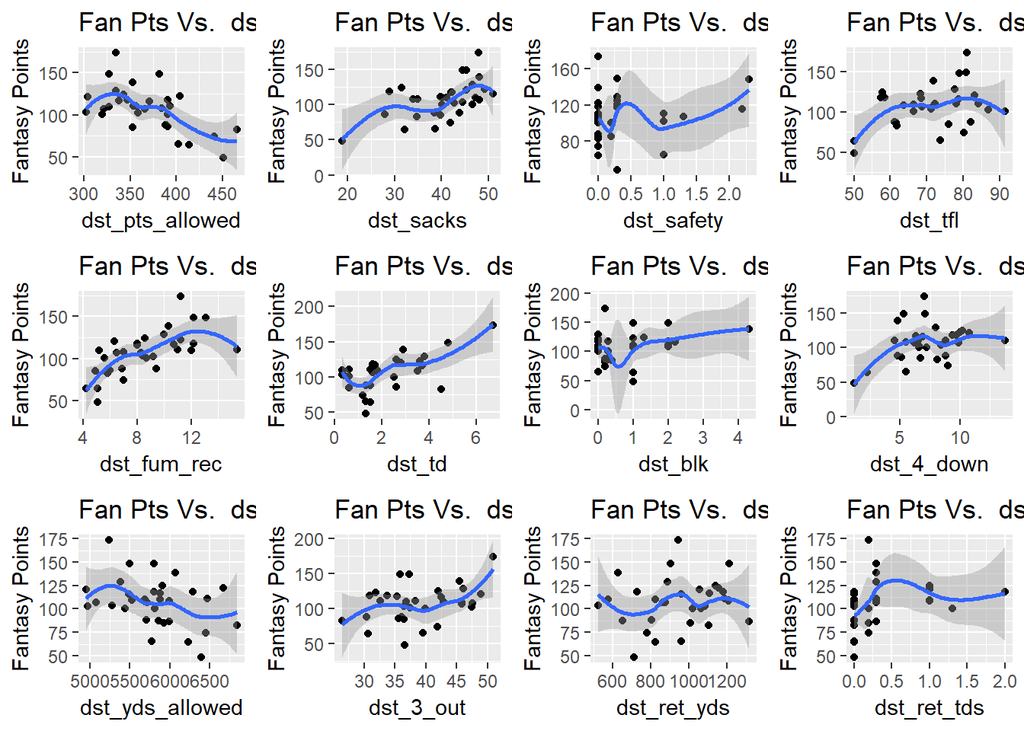

```r
dst_plot_cols <- dsts[, c(dst_cols, "site_pts")]

list <-lapply(dst_cols,
              function(col) qplot(x = dst_plot_cols[,col], y = dst_plot_cols[,"site_pts"], xlab = col, ylab = "Fantasy Points",                                     geom = c("point", "smooth"), main = paste("Fan Pts Vs. ", col)))

cowplot::plot_grid(plotlist = list)
```

There is musch more variance in the plots of the defensive metrics. This as a whole may be a reason to separate this position from the rest of the data. However, there are mostly positive relationships although not clearly so.

## Data Modeling

Now we will train a multivariable regression model with our dataset and then evaluate and tweak its performance as needed.

### Feature Engineering: Review of variables to features

There are certain variables we do not want to include in our model. We will drop those columns in out dataset

On inspection of the columns there we will remove the following from the dataset: These columns are not related to player performance

```r
# Remove these variables:
drop_these <- c("data_src","id", "src_id", "z", "note", "player", "team", "team", "status_game_opp", "z1", "forecast",
                "owner", "games", "bye", "fantasy_percent_owned","rankings_proj", "rankings_actual", "na")

player_data_for_model <- players[ ,!(names(players_data_out) %in% drop_these)]

head(player_data_for_model)
```

```
##   pos site_pts pass_att pass_comp pass_inc pass_yds pass_tds pass_int
## 1  QB   444.25      591       396      195     5297     51.1     14.1
## 2  QB   371.30      538       365      173     4013     31.9     13.9
## 3  QB   367.34      687       454      233     5297     35.1     17.0
## 4  QB   356.79      541       402      139     4542     39.2      6.4
## 5  QB   348.99      565       374      191     4976     35.5     10.1
## 6  QB   347.63      616       429      186     5021     32.8      8.7
##   passing_pick_six sacks pass_1st pass_40_yds rush_att rush_yds rush_tds
## 1              1.0  28.2      239        15.0     72.0    319.0      2.6
## 2              1.0  32.8      211         5.2    122.0    606.0      5.6
## 3              0.0  25.6      248        16.7     27.5    104.0      3.0
## 4              0.0  18.6      221         8.7     26.5     29.9      3.3
## 5              0.0  33.7      240        12.1     48.1    116.0      1.3
## 6              0.0  43.7      237        10.2     32.7    132.0      2.6
##   rush_1st rush_40_yds rec_tgt rec rec_yds rec_tds rec_1st rec_40_yds
```

[output cut: 27 more lines]

### Model Construction

First I will train the model with the raw data and then evaluate and tweak the model with new features, eliminate insignificant features, etc. Then compare my models to each other and see which performs best

Initial Model

```r
initial_train <- sample_n(player_data_for_model, round(nrow(player_data_for_model) * .8))
initial_test  <- sample_n(player_data_for_model, round(nrow(player_data_for_model) * .2))

initial_model <- lm(site_pts ~ rec_tgt + rec + rec_yds + rec_tds + rec_1st + rec_40_yds + ret_yds + ret_tds
                    + pass_att + pass_comp + pass_inc + pass_yds + pass_tds + pass_int + dst_pts_allowed + dst_sacks
                    + dst_safety + dst_tfl + dst_fum_rec + dst_td + dst_blk + dst_4_down + dst_yds_allowed + dst_3_out
                    + dst_ret_yds + dst_ret_tds + rush_att + rush_yds + rush_tds + rush_1st + rush_40_yds,
                    data = initial_train)

summary(initial_model)
```

```
##
## Call:
## lm(formula = site_pts ~ rec_tgt + rec + rec_yds + rec_tds + rec_1st +
##     rec_40_yds + ret_yds + ret_tds + pass_att + pass_comp + pass_inc +
##     pass_yds + pass_tds + pass_int + dst_pts_allowed + dst_sacks +
##     dst_safety + dst_tfl + dst_fum_rec + dst_td + dst_blk + dst_4_down +
##     dst_yds_allowed + dst_3_out + dst_ret_yds + dst_ret_tds +
##     rush_att + rush_yds + rush_tds + rush_1st + rush_40_yds,
##     data = initial_train)
##
## Residuals:
##    Min     1Q Median     3Q    Max
## -7.385 -1.191  0.088  1.161  9.617
##
## Coefficients:
##                   Estimate Std. Error t value Pr(>|t|)
## (Intercept)      0.9234506  0.4021107   2.297   0.0225 *
## rec_tgt         -0.0098961  0.0289244  -0.342   0.7326
## rec              0.5234587  0.0432831  12.094  < 2e-16 ***
## rec_yds          0.0952976  0.0049979  19.067  < 2e-16 ***
## rec_tds          5.9761264  0.1177892  50.736  < 2e-16 ***
## rec_1st          0.0750926  0.0805959   0.932   0.3524
## rec_40_yds       0.2853924  0.2851900   1.001   0.3180
## ret_yds          0.0008331  0.0014521   0.574   0.5667
## ret_tds          4.9451486  1.2245115   4.038 7.29e-05 ***
## pass_att         0.2042556  1.3626246   0.150   0.8810
## pass_comp       -0.2126204  1.3653132  -0.156   0.8764
## pass_inc        -0.2317828  1.3606542  -0.170   0.8649
## pass_yds         0.0393094  0.0024325  16.160  < 2e-16 ***
## pass_tds         4.2532387  0.1342751  31.676  < 2e-16 ***
## pass_int        -1.0038402  0.1427177  -7.034 2.18e-11 ***
## dst_pts_allowed -0.2814772  0.0374728  -7.512 1.21e-12 ***
## dst_sacks        0.1347648  0.1077393   1.251   0.2122
## dst_safety      -1.2364958  1.2596959  -0.982   0.3273
## dst_tfl          0.0976699  0.0751279   1.300   0.1949
## dst_fum_rec      3.7695161  0.2479068  15.205  < 2e-16 ***
## dst_td           8.4178897  0.4394558  19.155  < 2e-16 ***
## dst_blk          3.5640414  0.8908982   4.001 8.47e-05 ***
## dst_4_down       0.6510124  0.3510953   1.854   0.0650 .
## dst_yds_allowed  0.0016141  0.0030208   0.534   0.5936
## dst_3_out        0.1473467  0.0923485   1.596   0.1119
## dst_ret_yds     -0.0046790  0.0042452  -1.102   0.2715
## dst_ret_tds      8.9200869  1.9346552   4.611 6.59e-06 ***
## rush_att        -0.0323279  0.0168095  -1.923   0.0557 .
## rush_yds         0.1029724  0.0062801  16.397  < 2e-16 ***
## rush_tds         6.2099404  0.1681962  36.921  < 2e-16 ***
## rush_1st         0.0316325  0.0906450   0.349   0.7274
## rush_40_yds      0.0204665  0.4854936   0.042   0.9664
## ---
## Signif. codes:  0 '***' 0.001 '**' 0.01 '*' 0.05 '.' 0.1 ' ' 1
##
## Residual standard error: 2.651 on 235 degrees of freedom
## Multiple R-squared:  0.9991, Adjusted R-squared:  0.999
## F-statistic:  8708 on 31 and 235 DF,  p-value: < 2.2e-16
```

We will start with **backwards fitting** our parameters (Starting with all our features and removing them iteratively)

### Model Peformance Measure: Evaluation of Fit

From the summary of our initial model there are quite a few insignificant parameters (p-values > .05) We’ll Evaluate he model with them included first

```r
# We will use the model to predict with out test data
# Mean Squared Error (MSE) will be used as a performance measure
predicted <- predict(initial_model, newdata = initial_test, type = "response")

initial_MSE <- sum((predicted - initial_test$site_pts) ** 2) / nrow(initial_test)

initial_MSE
```

```
## [1] 5.354204
```

Second Model We will use **backwards fitting** and remove insignificant parameters

```r
second_train <- sample_n(player_data_for_model, round(nrow(player_data_for_model) * .8))
second_test  <- sample_n(player_data_for_model, round(nrow(player_data_for_model) * .2))

second_model <- lm(site_pts ~ rec + rec_yds + rec_tds + ret_tds + pass_yds + pass_tds + pass_int + dst_pts_allowed + dst_sacks
                              + dst_fum_rec + dst_td + dst_blk + dst_3_out + dst_ret_tds + rush_yds + rush_tds,
                    data = initial_train)

summary(second_model)
```

```
##
## Call:
## lm(formula = site_pts ~ rec + rec_yds + rec_tds + ret_tds + pass_yds +
##     pass_tds + pass_int + dst_pts_allowed + dst_sacks + dst_fum_rec +
##     dst_td + dst_blk + dst_3_out + dst_ret_tds + rush_yds + rush_tds,
##     data = initial_train)
##
## Residuals:
##     Min      1Q  Median      3Q     Max
## -7.9447 -1.3136 -0.1178  1.2301  9.6300
##
## Coefficients:
##                   Estimate Std. Error t value Pr(>|t|)
## (Intercept)      0.8685391  0.3543270   2.451 0.014922 *
## rec              0.5009483  0.0243716  20.555  < 2e-16 ***
## rec_yds          0.1002072  0.0020159  49.708  < 2e-16 ***
## rec_tds          6.0045818  0.1153898  52.037  < 2e-16 ***
## ret_tds          5.4286863  1.0335779   5.252 3.21e-07 ***
## pass_yds         0.0370423  0.0009032  41.012  < 2e-16 ***
## pass_tds         4.3408465  0.1099518  39.480  < 2e-16 ***
## pass_int        -1.0819458  0.1077252 -10.044  < 2e-16 ***
## dst_pts_allowed -0.2627483  0.0063356 -41.471  < 2e-16 ***
## dst_sacks        0.3090281  0.0813737   3.798 0.000183 ***
## dst_fum_rec      3.9015853  0.2221320  17.564  < 2e-16 ***
## dst_td           7.9923972  0.3470756  23.028  < 2e-16 ***
## dst_blk          2.5654450  0.5627447   4.559 8.06e-06 ***
## dst_3_out        0.2108628  0.0779557   2.705 0.007302 **
## dst_ret_tds      9.9931766  1.0564519   9.459  < 2e-16 ***
## rush_yds         0.0970720  0.0013600  71.374  < 2e-16 ***
## rush_tds         6.2570377  0.1537195  40.704  < 2e-16 ***
## ---
## Signif. codes:  0 '***' 0.001 '**' 0.01 '*' 0.05 '.' 0.1 ' ' 1
##
## Residual standard error: 2.674 on 250 degrees of freedom
## Multiple R-squared:  0.9991, Adjusted R-squared:  0.999
## F-statistic: 1.658e+04 on 16 and 250 DF,  p-value: < 2.2e-16
```

### Model Peformance Measure: Evaluation of Fit

```r
# We will use the model to predict with out test data
# Mean Squared Error (MSE) will be used as a performance measure
predicted <- predict(second_model, newdata = second_test, type = "response")

second_MSE<- sum((predicted - second_test$site_pts) ** 2) / nrow(second_test)

second_MSE
```

```
## [1] 4.453725
```

## Conclusions

At the end of our analysis we came out with two models attempting to predict season-wide fantasy football performance of NFL players using in game statistics. Our data cleaning consisted of detecting outliers which we defined as players in their respective positions whose aggregated in game performance across their position’s metrics were very low often close to zero. Next our exploration of our data involved devising an effcient way to determine correlations between variables which was a challenge since we had so many. So we used a correlogram to visualize this. We also viewed distributions of each variable independently and against the dependent site_pts variable. Finally our modeling produced to models whose errors (MSE) were 5.3542045 and 4.4537247 this is a difference 0.9004798 which is small considering both modesls did well in extrapolating to new data which was a subset of the players dataset. Eliminating variables that mostly showed weak relationships with the dependent variable, improved the model. This model works very well on this type of data and showed a strong R-squared value, however more data will improve statistical confidence.

Overall this model has the ability to predict fantasy scores and help draft players with high accuracy.